[figure not shown]

Zoë Farmer

# CSCI4446 - Chaotic Dynamics Homeworks - Problem Set 3

```python
import numpy as np
import matplotlib.pyplot as plt
import svgwrite as svg
from IPython.display import Image
from IPython.display import SVG
import random

%pylab inline
```

```
WARNING: pylab import has clobbered these variables: ['random']
`%matplotlib` prevents importing * from pylab and numpy
```

**0. Go to the googlelabs.com Julia site that’s listed on the course webpage and zoom into the Newton’s method. Find some really interesting area and turn in a plot of it.**

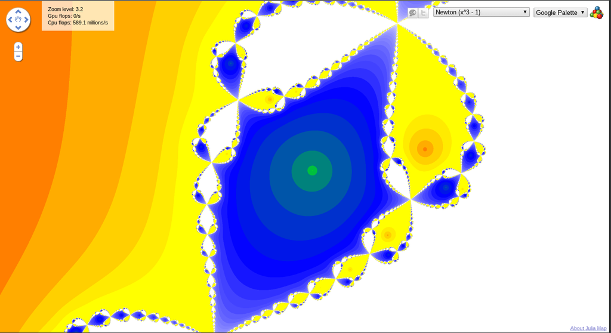

```python
Image(filename='fractal.png')
```

**1. Calculate (paper and pencil, not code) the capacity dimension for a middle-sixth-removed Cantor set.**

Let's first draw what this Cantor set would look like.

```python
def cantorset(dwg, iterations, fraction, x0, y0, width):
    if iterations == 0:
        return
    x, y = x0 + width, y0
    dwg.add(dwg.line((x0, y0), (x, y), stroke=svg.rgb(0, 0, 0, '%'), stroke_width=2))
    cantorset(dwg, iterations - 1, 1/6, x0, y0 + 5, (5 / 12) * width)
    cantorset(dwg, iterations - 1, 1/6, x0 + ((5 / 12) * width) + ((1 / 6) * width),
              y0 + 5, (5 / 12) * width)

dwg = svg.Drawing('cantor.svg', size=('10cm', '10cm'), profile='full')
dwg.viewbox(width=500, height=50)
lines = cantorset(dwg, 10, 1/6, 10, 10, 400)
dwg.save()
SVG(filename='cantor.svg')
```

[figure not shown]

Now lets look at how the number of line segments increases. As with the original cantor set, it remains $2^n$, however the length has now changed and is ${\left( \frac{5}{12} \right)}^n$.

Using the basic dimension formula:

$$ n = \frac{1}{s^D} $$

Where $n$ is the number of elements and $s$ is the scaling factor we plug in our values and solve for $D$.

$$ \begin{aligned} 2 &=& \frac{1}{{\left( \frac{5}{12} \right)}^D}\\ 2 &=& {\left( \frac{12}{5} \right)}^D\\ \log_{12 / 5} 2 &=& D\\ \frac{\ln 2}{\ln \frac{12}{5}} &=& D\\ \end{aligned} $$

Solving for a numerical approximation to $D$ we obtain

```python
np.log(2) / np.log(12/5)
```

```
0.79174406918855766
```

**2. a) Transform the following third-order ODE into three first-order ODEs.**

$$ 2 x^{\prime\prime\prime}(t) - 3 \tan \left( \frac{1}{2} \cdot x^{\prime\prime}(t) \right) + 16 \log\left( x^\prime(t) \right) - x(t) = 0 $$

We start by rewriting this to put the third order derivative on the left hand side.

$$ x^{\prime\prime\prime}(t) = \frac{3 \tan \left( \frac{1}{2} \cdot x^{\prime\prime}(t) \right) - 16 \log\left( x^\prime(t) \right) + x(t)}{2} $$

Now we set three helper variables, which we will define as the following.

$$ y_1 = x, y_2 = x^\prime, y_3 = x^{\prime\prime} $$

Using these we can rewrite the equation into several and take the derivative of each equation.

$$ \begin{aligned} y_1^\prime &= x^\prime = y_2\\ y_2^\prime &= x^{\prime\prime} = y_3\\ y_3^\prime &= x^{\prime\prime\prime} = \frac{3 \tan \left( \frac{1}{2} \cdot x^{\prime\prime}(t) \right) - 16 \log\left( x^\prime(t) \right) + x(t)}{2} = \frac{3 \tan \left( \frac{1}{2} \cdot y_3(t) \right) - 16 \log\left( y_2(t) \right) + y_1}{2} \end{aligned} $$

Yielding our final three equations.

$$ \begin{cases} y_1^\prime &= y_2\\ y_2^\prime &= y_3\\ y_3^\prime &= \frac{3 \tan \left( \frac{1}{2} \cdot y_3(t) \right) - 16 \log\left( y_2(t) \right) + y_1}{2} \end{cases} $$

**b) Transform the following set of first-order ODEs into a single higher-order ODE.**

$$ \begin{aligned} \dot{x} &=& y\\ \dot{y} &=& z\\ \dot{z} &=& yz + \log y \end{aligned} $$

Simply substituting in the "helper variables" we can come back to the original equation.

$$ x^\prime x^{\prime\prime} + \log x^\prime = x^{\prime\prime\prime} $$

**c) Are the systems in parts (a) and (b) of this problem linear or nonlinear? Why?**

These systems are nonlinear because they have nonlinear functions associated with them, namely $\tan$ and $\log$.

**3. a) Write a program that begins with a vertical line segment, then iterates the following operation: draw two line segments at right angles from the top of the previous segment, each $0.6$ times the length of that segment. Iterate until you can no longer discern differences between successive segments. Turn in a plot.**

```python
def fractalate(dwg, iterations, x0, y0, length, reduction, init_angle, branch_angle):
    if iterations == 0:
        return
    x = x0 + length * np.cos(init_angle)
    y = y0 + length * np.sin(init_angle)
    dwg.add(dwg.line((x0, y0), (x, y), stroke=svg.rgb(0, 0, 0, '%'), stroke_width=1))
    fractalate(dwg, iterations - 1, x, y, length * reduction, reduction,
               init_angle + branch_angle, branch_angle)
    fractalate(dwg, iterations - 1, x, y, length * reduction, reduction,
               init_angle - branch_angle, branch_angle)

dwg = svg.Drawing('fractaltree.svg', size=('20cm', '20cm'), profile='full')
dwg.viewbox(width=1000, height=1000)
lines = fractalate(dwg, 12, 500, 1000, 500, 0.6, -np.pi / 2, np.pi / 2)
dwg.save()
SVG(filename='fractaltree.svg')
```

[figure not shown]

**b) What happens to the tree if each segment is exactly half as long as the previous one? What if it is larger than $0.707$?**

Looking at the plots below we see the behavior differs in each case. In the first case, the "decay" rate, the rate at which the iterations are no longer distinguishable increases substantially and after only a few iterations we can no longer discern the difference between successive iterations.

For the other case, for when it is larger than $0.7$, the decay rate isn't large enough and the "branches" become intertwined to the point of no longer being able to discern one branch from the other.

In other words, in order to have a "nice" looking fractal binary tree, there is a very small range of values in which the scaling factor must lie.

```python
dwg = svg.Drawing('fractaltree0.5.svg', size=('20cm', '20cm'), profile='full')
dwg.viewbox(width=1000, height=1000)
lines = fractalate(dwg, 10, 500, 1000, 500, 0.5, -np.pi / 2, np.pi / 2)
dwg.save()
SVG(filename='fractaltree0.5.svg')
```

[figure not shown]

```python
dwg = svg.Drawing('fractaltree0.3.svg', size=('20cm', '20cm'), profile='full')
dwg.viewbox(width=1000, height=1000)
lines = fractalate(dwg, 10, 500, 1000, 500, 0.3, -np.pi / 2, np.pi / 2)
dwg.save()
SVG(filename='fractaltree0.3.svg')
```

[figure not shown]

```python
dwg = svg.Drawing('fractaltree0.8.svg', size=('20cm', '20cm'), profile='full')
dwg.viewbox(width=1000, height=1000)
lines = fractalate(dwg, 10, 500, 1000, 300, 0.8, -np.pi / 2, np.pi / 2)
dwg.save()
SVG(filename='fractaltree0.8.svg')
```

[figure not shown]

**Playing around with fractals.**

```python
def fractalate_diffred(dwg, iterations, x0, y0, length,
                       reduction_left, reduction_right,
                       init_angle, branch_angle_left, branch_angle_right):
    if iterations == 0:
        return
    x = x0 + length * np.cos(init_angle)
    y = y0 + length * np.sin(init_angle)
    dwg.add(dwg.line((x0, y0), (x, y),
                     stroke=svg.rgb(0, 0, 0, '%'),
                     stroke_width=1))
    fractalate_diffred(dwg, iterations - 1, x, y,
               length * reduction_left, reduction_left, reduction_right,
               init_angle + branch_angle_left, branch_angle_left, branch_angle_right)
    fractalate_diffred(dwg, iterations - 1, x, y,
               length * reduction_right, reduction_left, reduction_right,
               init_angle - branch_angle_right, branch_angle_left, branch_angle_right)

dwg = svg.Drawing('fractaltreediff.svg', size=('20cm', '20cm'), profile='full')
dwg.viewbox(width=1000, height=1000)
lines = fractalate_diffred(dwg, 12, 500, 1000, 270, 0.7, 0.65,
                           -np.pi / 2, np.pi / 3, 2 * np.pi / 9)
dwg.save()
SVG(filename='fractaltreediff.svg')
```

[figure not shown]

```python
def fractalate_rand(dwg, iterations, x0, y0, length,
                       reduction_left, reduction_right,
                       init_angle, branch_angle_left, branch_angle_right):
    if iterations == 0:
        return
    length = (random.random() + 0.5) * length if length != 200 else 200
    x = x0 + length * np.cos(init_angle)
    y = y0 + length * np.sin(init_angle)
    dwg.add(dwg.line((x0, y0), (x, y),
                     stroke=svg.rgb(0, 0, 0, '%'),
                     stroke_width=1))
    fractalate_rand(dwg, iterations - 1, x, y,
               length * reduction_left, reduction_left, reduction_right,
               init_angle + branch_angle_left*random.random(),
               branch_angle_left, branch_angle_right)
    fractalate_rand(dwg, iterations - 1, x, y,
               length * reduction_right, reduction_left, reduction_right,
               init_angle - branch_angle_right*random.random(),
               branch_angle_left, branch_angle_right)

dwg = svg.Drawing('fractaltreerand.svg', size=('20cm', '20cm'), profile='full')
dwg.viewbox(width=1000, height=1000)
lines = fractalate_rand(dwg, 12, 500, 1000, 400, 0.6, 0.6,
                        -np.pi / 2, np.pi / 3, np.pi / 3)
dwg.save()
SVG(filename='fractaltreerand.svg')
```

[figure not shown]

Sun 03 May 2015

By Zoë Farmer

Notes notes chaos